# Trabalho 02 - Estatística Computacional

Heit or Carvalho Pinheiro - 11833351

2023-05-24

## Questão 1

Vamos resolver o problema através de simulações de Monte Carlo. Para simular o comportamento do sistema, amostraremos cada possível estado, como um vetor de sete elementos, representando os estados $N$ vezes e definido as condições em que a amostra faria o sistema funcionar

```r
set.seed(42)

#numero de simulações Monte-Carlo
R <- 10000

#vetor inicial
v <- c(1,2,3,4,5,6,7)

#definindo as sequencias de condicoes
sequences <- list(
  c(1,2,3),
  c(1,4,5,3),
  c(1,4,7),
  c(6,5,3),
  c(6,7)
)

#amostrando os valores 5000 vezes
monte_carlo_samples <- lapply(1:R, function(x) sample(v, size = length(v), replace = FALSE))

#filtrando as condicoes
monte_carlo_samples_filtered <- monte_carlo_samples[sapply(monte_carlo_samples, function(x) any(sapply(sequences, function(seq) identical(x[1:length(seq)], seq))))]

length(monte_carlo_samples_filtered)
```

```
## [1] 379
```

```r
prop.sucesso <- length(monte_carlo_samples_filtered)/R
erro.MC <- prop.sucesso*(1-prop.sucesso)/(R-1)

#estimativa pontual do sistema funcionar
prop.sucesso
```

```
## [1] 0.0379
```

```r
#IC 95% com aproximacao normal da estimativa
IC.li <- prop.sucesso - qnorm(0.975)*erro.MC
IC.ls <- prop.sucesso + qnorm(0.975)*erro.MC
IC.MC <- cbind(IC.li, IC.ls)

IC.MC
```

```
##           IC.li      IC.ls
## [1,] 0.03789285 0.03790715
```

## Questão 2

2. O Modelo de Regressão baseadomonte na curva de Ricker pode ser o seguinte

$$Y_i = \beta_ix_iexp(-\beta_2x_i) + \epsilon_i,~~~ i = 1,..,n$$

| x | y |
| --- | --- |
| 84.30 | 0.28 |
| 97.30 | 0.74 |
| 10.73 | 4.52 |
| 80.65 | 0.60 |
| 34.49 | 1.17 |
| 77.40 | 0.31 |
| 52.94 | 0.70 |
| 22.92 | 3.53 |
| 76.30 | 0.40 |
| 99.65 | 0.08 |

[output cut: 15 more lines]

### Visualizando os dados

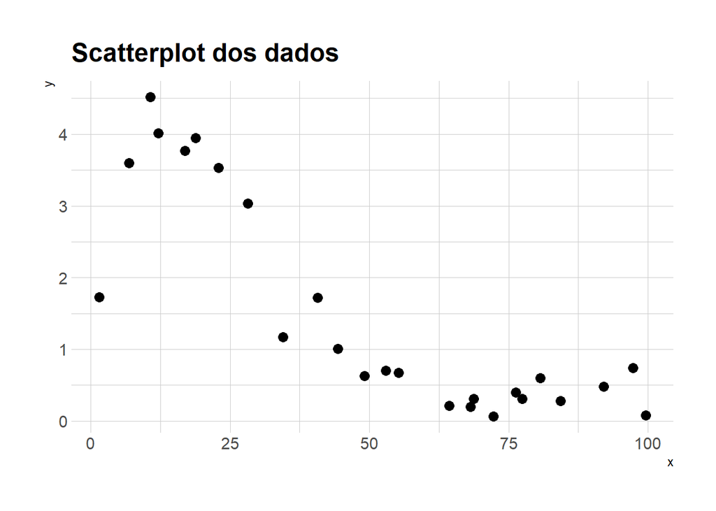

a)

```
##
## Formula: y ~ ricker.model(x, beta1, beta2)
##
## Parameters:
##       Estimate Std. Error t value Pr(>|t|)
## beta1 0.956875   0.062322   15.35  1.4e-13 ***
## beta2 0.082204   0.003329   24.69  < 2e-16 ***
## ---
## Signif. codes:  0 '***' 0.001 '**' 0.01 '*' 0.05 '.' 0.1 ' ' 1
##
## Residual standard error: 0.3322 on 23 degrees of freedom
##
## Number of iterations to convergence: 6
## Achieved convergence tolerance: 9.364e-06
```

```r
summary <- summary(ricker.fit)
summary$coefficients
```

```
##         Estimate  Std. Error  t value     Pr(>|t|)
## beta1 0.95687487 0.062321724 15.35379 1.402333e-13
## beta2 0.08220413 0.003328944 24.69376 4.668686e-18
```

```r
#se beta1
summary$coefficients[[1,2]]
```

```
## [1] 0.06232172
```

```r
#se beta 2
summary$coefficients[[2,2]]
```

```
## [1] 0.003328944
```

## Plotando os dados com o modelo ajustado

| x | y | prednls |
| --- | --- | --- |
| 84.30 | 0.28 | 0.07890513 |
| 97.30 | 0.74 | 0.03128096 |
| 10.73 | 4.52 | 4.24996434 |
| 80.65 | 0.60 | 0.10190371 |
| 34.49 | 1.17 | 1.93743769 |
| 77.40 | 0.31 | 0.12774802 |

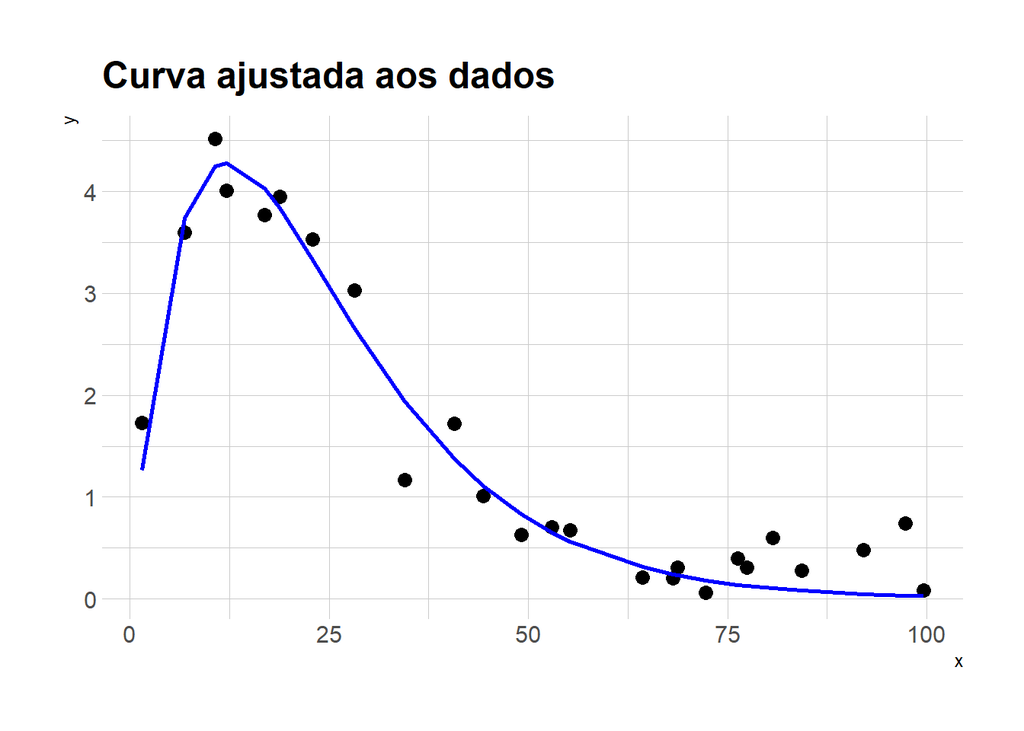

A partir do gráfico com o modelo ajustado aos dados, parece que o modelo, de fato, faz um bom ajuste.

Ainda sim, podemos verificar a qualidade do ajuste verificando se as suposições feitas, inicialmente são válidas. São elas:

- A normalidade da distribuição dos resíduos.
- A homegeneidade da variância dos resíduos (homocedasticidade).
- A independência dos resíduos.

### Verificando as suposições dos resíduos

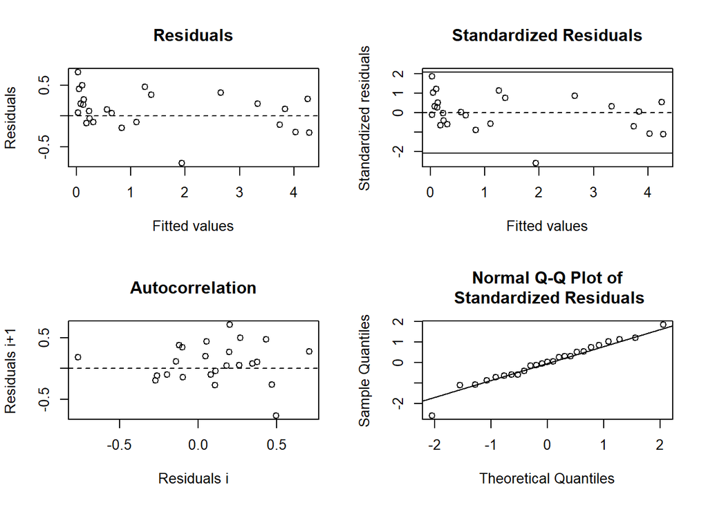

```r
ricker.residuals <- nlsResiduals(ricker.fit)
plot(ricker.residuals)
```

O gráfico superior direito que corresponde aos resíduos normalizados evidencia que ainda existe alguma variância nos resíduos, uma vez que os valores não estão uniformemente distribuídos ao redor de 0.

Por fim, a única suposição que parece ter sido atendida foi a suposição da normalidade dos resíduos que observa no gráfico inferior direito, acima.

### b) Obtennha estimativas *bootstrap* dos erros padrões dos estimadores de $\beta_1$ e $\beta_2$ e compare com os resultados do item 2a**

Do item anterior temos que os erros padrões de $\beta_1$ e $\beta_2$ são:

$$se(\beta_1) = 0.0623
\\
se(\beta_2) = 0.0033$$

### Estimativa *bootstrap* dos erros padrão

Para realizarmos a estimativa bootstrap dos erros padrão dos estimadores iremos reamostrar os dados com reposição, reajustando um modelo não-linear mínimos quadrados com o auxílio da função `nls()` e, ajustado os valores, calculamos a média dos erros padrão para cada estimador, obtendo assim uma estimativa dos erros *bootstrap*.

Vamos realizar uma estimativa a partir de 5000 amostras boostrap

```r
B = 1:5000
se.beta1.boot <- c()
se.beta2.boot <- c()
idxs.dados <- c()

#realizando a reamostragem dos dados
set.seed(42)
idxs.dados[B] <- replicate(tail(B, n=1),sample(1:length(dados.df$x), size = length(dados.df$x), replace = TRUE), simplify = FALSE)

for (b in B){

  #ajustando um modelo de minimos quadrados nao-linear
  ricker.fit <- nls(y ~ ricker.model(x, beta1, beta2), data = dados.df[as.double(idxs.dados[[b]]),], start = list(beta1 = 0.1, beta2 = 0.1), control = nls.control(minFactor = 1/4096), algorithm = "default")

  #summary do modelo
  summary.mod <- summary(ricker.fit)

  #erro padrao beta1
  se.beta1.boot <- summary.mod$coefficients[[1,2]]

  #erro padrao beta2
  se.beta2.boot <- summary.mod$coefficients[[2,2]]
}

#media do erro padrao do estimador beta1
cbind(mean(se.beta1.boot), mean(se.beta2.boot))
```

```
##            [,1]        [,2]
## [1,] 0.06287447 0.003169689
```

As estimativas *bootstrap* dos erros padrão de $\beta_1$ e $\beta_2$ são respectivamente:

|  | beta1 | beta2 |
| --- | --- | --- |
| Erro padrao | 0.06232172 | 0.003328944 |
| Erro padrao bootstrap | 0.06287447 | 0.003169689 |

Como podemos perceber pela tabela acima, os erros bootstrap são bem próximos dos erro obtido pelo ajuste do modelo.

#### c) Estudo de Simulação do Viés dos estimadores

Estudo de vies dos estimadores beta1 e beta2

Verdadeiros valores de beta1 e beta2

beta1 = 0.956 beta2 = 0.082

A ideia sera para cada valor da amostra, realizar N simulacoes do modelo, para cada simular computar o intervalo de confianca, e por fim computar a probabilidade do intervalo conter o verdadeiro valor do parametro considerando o espaco amostral como o espaco de todas as amostragens bootstrap.

### Para $n < 25$

Vamos selecionar uma amostra de tamanho $n = 10$ e realizaremos 1000 simulaçõe Bootstrap

Dessa vez utilizaremos a função `bootstraps()` do R para realizar as reamostragens.

```r
set.seed(1234)
#selecionando as 10 primeiras ocorrencias dos dados
dados.df.10 <- dados.df[sample(nrow(dados.df),10),]
#realizando 1000 amostragens bootsrap
boots.10 <- bootstraps(dados.df.10, times = 1000)
```

```r
#redefinindo a funcao ricker
ricker.model <- function(x, beta1, beta2){
  return(beta1 * x * exp(-beta2*x))
}

#ajustando o modelo para cada um das 1000 amostras bootstrap
coeffs.10 <-
  boots.10 %>%
  mutate(
    model = map(
      splits, ~nls(y ~ ricker.model(x, beta1, beta2), start = list(beta1 = 0.3, beta2 = 0.1), algorithm = "default", data = analysis(.x))
    ),
    coef_info = map(model, tidy)
  )

coeffs.10 %>%
  unnest(coef_info)
```

| splits | id | model | term | estimate | std.error | statistic | p.value |
| --- | --- | --- | --- | --- | --- | --- | --- |
|  | Bootstrap0001 |  | beta1 | 1.02594719 | 0.096759195 | 10.6030976 | 5.472944e-06 |
|  | Bootstrap0001 |  | beta2 | 0.08138028 | 0.005068447 | 16.0562547 | 2.271292e-07 |
|  | Bootstrap0002 |  | beta1 | 1.34465978 | 0.163940988 | 8.2020963 | 3.647385e-05 |
|  | Bootstrap0002 |  | beta2 | 0.09429514 | 0.005178595 | 18.2086359 | 8.505794e-08 |
|  | Bootstrap0003 |  | beta1 | 1.02259418 | 0.139847153 | 7.3122274 | 8.290243e-05 |
|  | Bootstrap0003 |  | beta2 | 0.08902472 | 0.006304692 | 14.1203907 | 6.150617e-07 |
|  | Bootstrap0004 |  | beta1 | 0.18549372 | 0.033468090 | 5.5424054 | 5.458163e-04 |
|  | Bootstrap0004 |  | beta2 | 0.04954852 | 0.003396903 | 14.5863823 | 4.785317e-07 |
|  | Bootstrap0005 |  | beta1 | 0.16343023 | 0.047145266 | 3.4665247 | 8.485979e-03 |
|  | Bootstrap0005 |  | beta2 | 0.04643480 | 0.005799687 | 8.0064319 | 4.341635e-05 |

[output cut: 1990 more lines]

### Para $n = 25$

Para $n = 25$ usaremos a nossa amostra original